# 🛒 Retail Sales Data Analysis Project

# Numerical Data

### Age (HISTOGRAM)

- Average customer age
- Youngest customer
- Oldest customer
- Median age
- Spread of ages

### BOXPLOT

-- Detects

- Outliers
- Extreme ages

### Quantity (Count Plot)

- Do customers mostly buy one item?
- How many buy four items?

### Price per Unit(Histogram)

- Cheap products?
- Premium products?
- Right skew?

```python
df['age'].describe()
```

```
count    1987.000000
mean       41.351283
std        13.662653
min        18.000000
25%        29.000000
50%        42.000000
75%        53.000000
max        64.000000
Name: age, dtype: float64
```

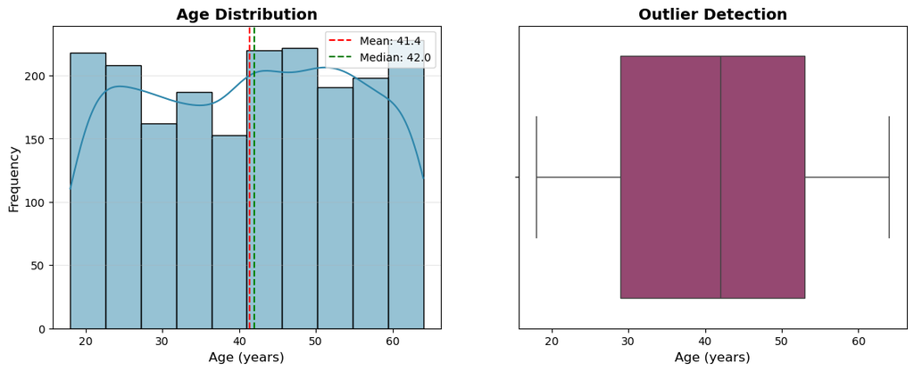

```python
# Plot 1: Histogram on left
fig, axes = plt.subplots(1, 2, figsize=(14, 5))
sns.histplot(df['age'], bins=10, kde=True, ax=axes[0], color='#2E86AB')
axes[0].set_title('Age Distribution', fontweight='bold', fontsize=14)
axes[0].set_xlabel('Age (years)', fontsize=12)
axes[0].set_ylabel('Frequency', fontsize=12)
axes[0].axvline(df['age'].mean(), color='red', linestyle='--',
                label=f'Mean: {df["age"].mean():.1f}')
axes[0].axvline(df['age'].median(), color='green', linestyle='--',
                label=f'Median: {df["age"].median():.1f}')
axes[0].legend()
axes[0].grid(axis='y', alpha=0.3)

# Plot 2: Boxplot on right
sns.boxplot(x=df['age'], ax=axes[1], color='#A23B72')
axes[1].set_title('Outlier Detection', fontweight='bold', fontsize=14)
axes[1].set_xlabel('Age (years)', fontsize=12)
```

```python
# Quantity
df['quantity'].describe()
```

```
count    1987.00000
mean        2.51384
std         1.13277
min         1.00000
25%         1.00000
50%         3.00000
75%         4.00000
max         4.00000
Name: quantity, dtype: float64
```

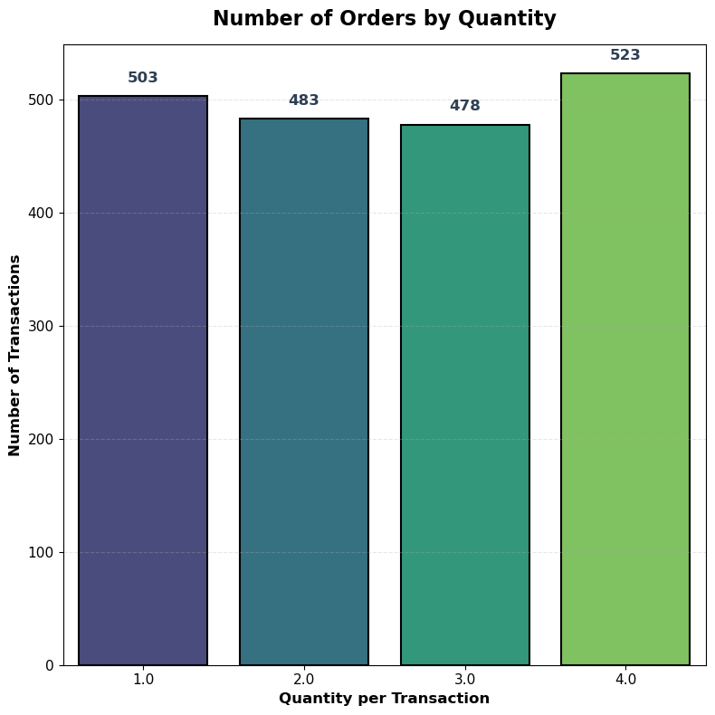

```python
plt.figure(figsize=(8, 8))
sns.countplot(data=df, x='quantity', palette='viridis', edgecolor='black', linewidth=1.5)
plt.title('Number of Orders by Quantity', fontweight='bold', fontsize=16, pad=15)
plt.xlabel('Quantity per Transaction', fontsize=12, fontweight='semibold')
plt.ylabel('Number of Transactions', fontsize=12, fontweight='semibold')
plt.xticks(fontsize=11)
plt.yticks(fontsize=11)
plt.grid(axis='y', alpha=0.3, linestyle='--')

# Add value labels on bars
for i, bar in enumerate(plt.gca().patches):
    height = bar.get_height()
    plt.text(bar.get_x() + bar.get_width()/2., height + 10,
             f'{int(height)}', ha='center', va='bottom',
             fontweight='bold', fontsize=12, color='#2E4053')

plt.tight_layout()
plt.show()
```

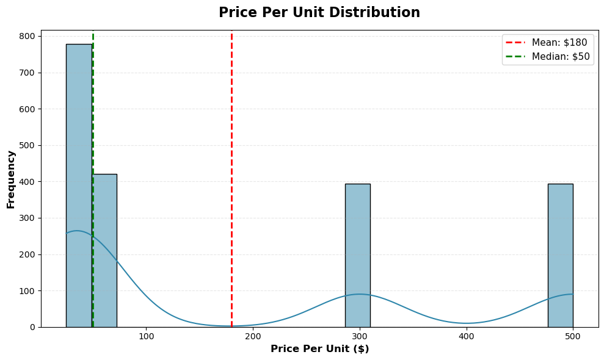

```python
# Price per unit
plt.figure(figsize=(10, 6))
sns.histplot(df['price_per_unit'], bins=20, kde=True, color='#2E86AB', edgecolor='black', linewidth=1)
plt.title('Price Per Unit Distribution', fontweight='bold', fontsize=16, pad=15)
plt.xlabel('Price Per Unit ($)', fontsize=12, fontweight='semibold')
plt.ylabel('Frequency', fontsize=12, fontweight='semibold')
plt.grid(axis='y', alpha=0.3, linestyle='--')

# Add mean and median lines
mean_price = df['price_per_unit'].mean()
median_price = df['price_per_unit'].median()
plt.axvline(mean_price, color='red', linestyle='--', linewidth=2,
            label=f'Mean: ${mean_price:.0f}')
plt.axvline(median_price, color='green', linestyle='--', linewidth=2,
            label=f'Median: ${median_price:.0f}')
plt.legend(fontsize=11)

plt.tight_layout()
plt.show()
```

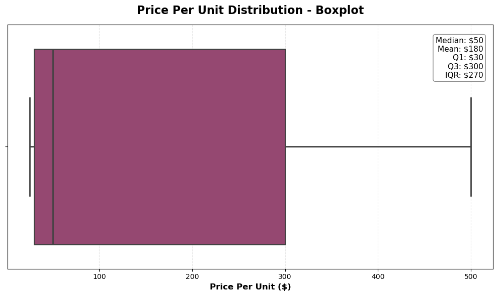

```python
plt.figure(figsize=(10, 6))
sns.boxplot(x=df['price_per_unit'], color='#A23B72', linewidth=2)
plt.title('Price Per Unit Distribution - Boxplot', fontweight='bold', fontsize=16, pad=15)
plt.xlabel('Price Per Unit ($)', fontsize=12, fontweight='semibold')
plt.grid(axis='x', alpha=0.3, linestyle='--')

# Add statistics annotation
q1 = df['price_per_unit'].quantile(0.25)
q3 = df['price_per_unit'].quantile(0.75)
iqr = q3 - q1
median = df['price_per_unit'].median()
mean = df['price_per_unit'].mean()

stats_text = f'Median: ${median:.0f}\nMean: ${mean:.0f}\nQ1: ${q1:.0f}\nQ3: ${q3:.0f}\nIQR: ${iqr:.0f}'
plt.text(0.98, 0.95, stats_text, transform=plt.gca().transAxes,
         fontsize=11, verticalalignment='top', horizontalalignment='right',
         bbox=dict(boxstyle='round', facecolor='white', alpha=0.9, edgecolor='gray'))

plt.tight_layout()
plt.show()
```

```python
#COGS
df['cogs'].describe()
```

```
count    1987.000000
mean       95.081933
std       122.032280
min         6.250000
25%        13.000000
50%        27.500000
75%       147.000000
max       620.000000
Name: cogs, dtype: float64
```

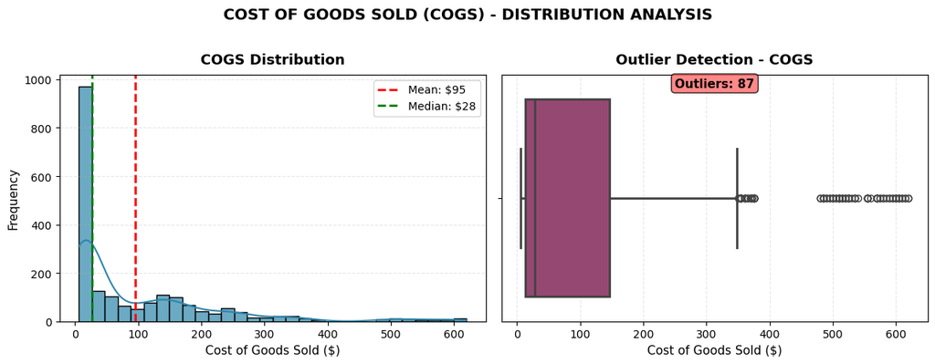

```python
# COGS - Distribution Analysis (Compact Layout)
fig, axes = plt.subplots(1, 2, figsize=(12, 4.5))

# Plot 1: Histogram with KDE (Left)
sns.histplot(df['cogs'], bins=30, kde=True, ax=axes[0], color='#2E86AB', edgecolor='black', linewidth=1, alpha=0.7)
axes[0].set_title('COGS Distribution', fontweight='bold', fontsize=13, pad=10)
axes[0].set_xlabel('Cost of Goods Sold ($)', fontsize=11)
axes[0].set_ylabel('Frequency', fontsize=11)

# Add mean and median lines
mean_cogs = df['cogs'].mean()
median_cogs = df['cogs'].median()
axes[0].axvline(mean_cogs, color='red', linestyle='--', linewidth=2,
                label=f'Mean: ${mean_cogs:.0f}')
axes[0].axvline(median_cogs, color='green', linestyle='--', linewidth=2,
                label=f'Median: ${median_cogs:.0f}')
axes[0].legend(fontsize=10)
axes[0].grid(axis='y', alpha=0.3, linestyle='--')

# Plot 2: Boxplot (Right)
sns.boxplot(x=df['cogs'], ax=axes[1], color='#A23B72', linewidth=2, fliersize=6)
axes[1].set_title('Outlier Detection - COGS', fontweight='bold', fontsize=13, pad=10)
axes[1].set_xlabel('Cost of Goods Sold ($)', fontsize=11)
axes[1].grid(axis='x', alpha=0.3, linestyle='--')

# Add outlier count annotation
q1 = df['cogs'].quantile(0.25)
q3 = df['cogs'].quantile(0.75)
iqr = q3 - q1
outliers = df[(df['cogs'] < q1 - 1.5*iqr) | (df['cogs'] > q3 + 1.5*iqr)]
axes[1].text(0.5, 0.95,
             f'Outliers: {len(outliers)}',
             transform=axes[1].transAxes,
             ha='center', fontweight='bold', fontsize=11,
             bbox=dict(boxstyle='round', facecolor='#FF6B6B', alpha=0.8))

plt.suptitle('COST OF GOODS SOLD (COGS) - DISTRIBUTION ANALYSIS',
             fontsize=14, fontweight='bold', y=1.02)
plt.tight_layout()
plt.show()
```

```python
#TOTAL_SALE
df['total_sale'].describe()
```

```
count    1987.000000
mean      457.086059
std       560.862242
min        25.000000
25%        60.000000
50%       150.000000
75%       900.000000
max      2000.000000
Name: total_sale, dtype: float64
```

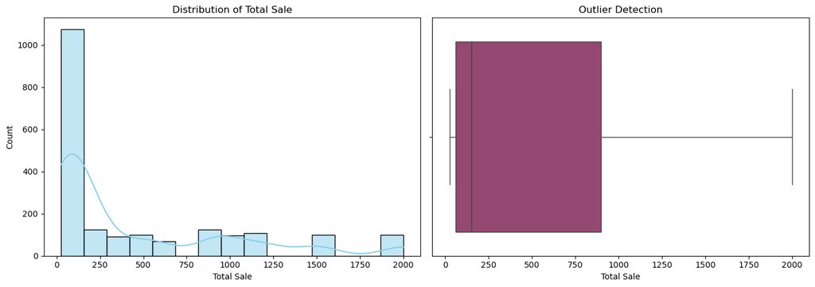

```python
fig, axes = plt.subplots(1, 2, figsize=(14, 5))

# Histogram
sns.histplot(df["total_sale"], kde=True, ax=axes[0], color="skyblue")
axes[0].set_title("Distribution of Total Sale")
axes[0].set_xlabel("Total Sale")

# Boxplot
sns.boxplot(x=df["total_sale"], ax=axes[1], color="#A23B72")
axes[1].set_title("Outlier Detection")
axes[1].set_xlabel("Total Sale")

plt.tight_layout()
plt.show()
```

## Categorical Columns

### Gender

- COUNTPLOT

### Category

```python
df['gender'].value_counts()
```

```
gender
Female    1012
Male       975
Name: count, dtype: int64
```

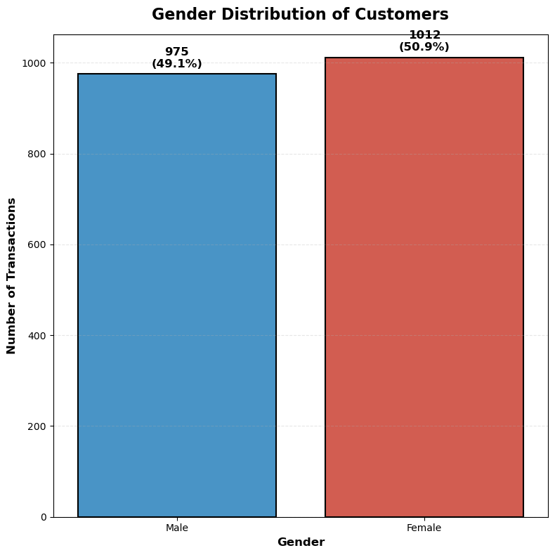

```python
plt.figure(figsize=(8, 8
                   ))
sns.countplot(data=df, x='gender', palette=['#3498DB', '#E74C3C'],
              edgecolor='black', linewidth=1.5)
plt.title('Gender Distribution of Customers', fontweight='bold', fontsize=16, pad=15)
plt.xlabel('Gender', fontsize=12, fontweight='semibold')
plt.ylabel('Number of Transactions', fontsize=12, fontweight='semibold')
plt.grid(axis='y', alpha=0.3, linestyle='--')

# Add value labels on bars
total = len(df)
for i, bar in enumerate(plt.gca().patches):
    height = bar.get_height()
    percentage = (height / total) * 100
    plt.text(bar.get_x() + bar.get_width()/2., height + 10,
             f'{int(height)}\n({percentage:.1f}%)',
             ha='center', va='bottom', fontweight='bold', fontsize=12)

plt.tight_layout()
plt.show()
```

```python
#category
df['category'].value_counts()
```

```
category
Clothing       698
Electronics    678
Beauty         611
Name: count, dtype: int64
```

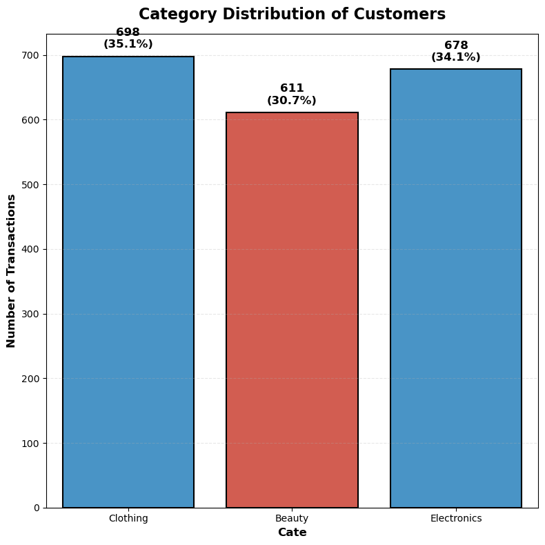

```python
plt.figure(figsize=(8, 8
                   ))
sns.countplot(data=df, x='category', palette=['#3498DB', '#E74C3C'],
              edgecolor='black', linewidth=1.5)
plt.title('Category Distribution of Customers', fontweight='bold', fontsize=16, pad=15)
plt.xlabel('Cate', fontsize=12, fontweight='semibold')
plt.ylabel('Number of Transactions', fontsize=12, fontweight='semibold')
plt.grid(axis='y', alpha=0.3, linestyle='--')

# Add value labels on bars
total = len(df)
for i, bar in enumerate(plt.gca().patches):
    height = bar.get_height()
    percentage = (height / total) * 100
    plt.text(bar.get_x() + bar.get_width()/2., height + 10,
             f'{int(height)}\n({percentage:.1f}%)',
             ha='center', va='bottom', fontweight='bold', fontsize=12)

plt.tight_layout()
plt.show()
```

## DATE & TIME

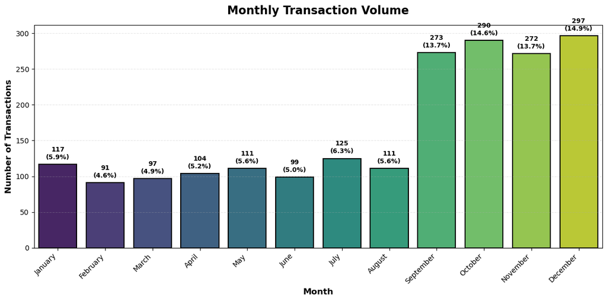

```python
# Create Month column if not exists
df["Month"] = df["sale_date"].dt.month_name()

# Order months correctly
month_order = ['January', 'February', 'March', 'April', 'May', 'June',
               'July', 'August', 'September', 'October', 'November', 'December']

plt.figure(figsize=(12, 6))
sns.countplot(data=df, x='Month', order=month_order,
              palette='viridis', edgecolor='black', linewidth=1.5)
plt.title('Monthly Transaction Volume', fontweight='bold', fontsize=16, pad=15)
plt.xlabel('Month', fontsize=12, fontweight='semibold')
plt.ylabel('Number of Transactions', fontsize=12, fontweight='semibold')
plt.xticks(rotation=45, ha='right')
plt.grid(axis='y', alpha=0.3, linestyle='--')

# Add value labels on bars
total = len(df)
for i, bar in enumerate(plt.gca().patches):
    height = bar.get_height()
    percentage = (height / total) * 100
    plt.text(bar.get_x() + bar.get_width()/2., height + 5,
             f'{int(height)}\n({percentage:.1f}%)',
             ha='center', va='bottom', fontweight='bold', fontsize=9)

plt.tight_layout()
plt.show()
```

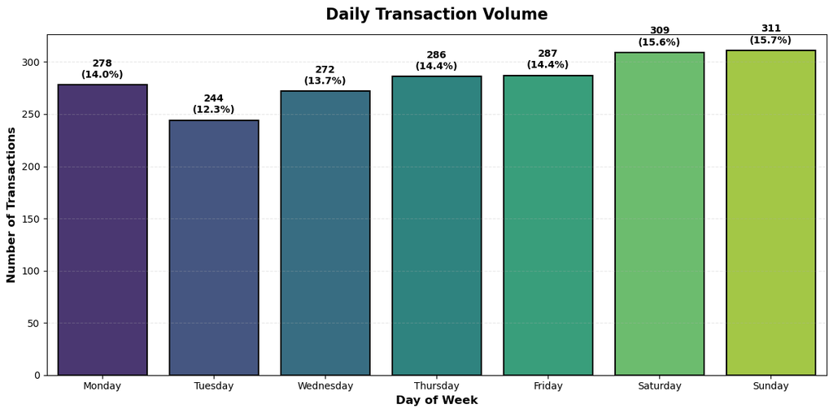

```python
# Create Day column if not exists
df["Day"] = df["sale_date"].dt.day_name()

# Order days correctly (Monday to Sunday)
day_order = ['Monday', 'Tuesday', 'Wednesday', 'Thursday', 'Friday', 'Saturday', 'Sunday']

plt.figure(figsize=(12, 6))
sns.countplot(data=df, x='Day', order=day_order,
              palette='viridis', edgecolor='black', linewidth=1.5)
plt.title('Daily Transaction Volume', fontweight='bold', fontsize=16, pad=15)
plt.xlabel('Day of Week', fontsize=12, fontweight='semibold')
plt.ylabel('Number of Transactions', fontsize=12, fontweight='semibold')
plt.grid(axis='y', alpha=0.3, linestyle='--')

# Add value labels on bars
total = len(df)
for i, bar in enumerate(plt.gca().patches):
    height = bar.get_height()
    percentage = (height / total) * 100
    plt.text(bar.get_x() + bar.get_width()/2., height + 5,
             f'{int(height)}\n({percentage:.1f}%)',
             ha='center', va='bottom', fontweight='bold', fontsize=10)

plt.tight_layout()
plt.show()
```

```python
df.to_csv("retail_sales_clean.csv", index=False)
```

# DEEP ANALYSIS

#### ANALYTICAL DATASET

The cleaned dataframe below is treated as the analytical source of truth.

All business metrics, customer analysis, profitability analysis, and dashboard outputs will be derived from this dataset.

```python
#dedicated dataframe keeping original safe
df_gold=df.copy()


print("Analytical dataset created")
print(f"Rows: {df_gold.shape[0]:,}")
print(f"Columns: {df_gold.shape[1]:,}")
```

```
Analytical dataset created
Rows: 1,987
Columns: 13
```

### INSIGHT 1

Data Retention Rate Data retention rate measures how much of the original dataset remains usable after data cleaning.

A high retention rate indicates that cleaning removed relatively few records while preserving most of the original information.

```python
#DATA RETENTION RATE
raw_rows=2000
clean_rows=len(df_gold)
rows_removed=raw_rows-clean_rows
retention_rate = (clean_rows / raw_rows) * 100
removal_rate = (rows_removed / raw_rows) * 100

retention_summary = pd.DataFrame({
    "Metric": [
        "Raw Records",
        "Clean Records",
        "Records Removed",
        "Retention Rate",
        "Removal Rate"
    ],
    "Value": [
        raw_rows,
        clean_rows,
        rows_removed,
        f"{retention_rate:.2f}%",
        f"{removal_rate:.2f}%"
    ]
})

display(retention_summary)
```

|  | Metric | Value |
| --- | --- | --- |
| 0 | Raw Records | 2000 |
| 1 | Clean Records | 1987 |
| 2 | Records Removed | 13 |
| 3 | Retention Rate | 99.35% |
| 4 | Removal Rate | 0.65% |